# Mittal-CustomerSwitchingSatisfactionLoyalty-1998-JSM.pdf

Converted from PDF `Mittal-CustomerSwitchingSatisfactionLoyalty-1998-JSM.pdf` · 18 pages · anchors: page `#pN`, block `#pN-bK`

Page 1

THE JOURNAL OF SERVICES MARKETING, VOL. 12 NO. 3 1998, pp. 177-194 © MCB UNIVERSITY PRESS, 0887-6045 177

**Introduction** Customer loyalty is increasingly being recognized by American businesses as a path to long-term business profitability. Consider two firms, say two hospitals, “A” and “B”, with identical facilities and capacity. Both have the same patient load, and consequently the same degree of facility utilization. However, hospital “A” has a loyal following of patients. In contrast, hospital “B” fills its facilities by acquiring new patients every year because the old patients never return. Which one has greater profitability? Or, in the case of non-profit hospitals, which one is being run more cost-efficiently?

The answer is very clear: without question, it is hospital “A” – the one with a loyal patient following. This is because finding new customers and doing business with them takes time, effort, and money. Hospital “B” for example, has to invest heavily in advertising to consumers and in personal selling to physicians, so as to attract new patients. Then, it has to spend the effort and precious employee time in setting up new patient records, for explaining the hospital procedures, and for understanding each patient’s individual needs, and guiding them through the treatment procedures.

The same is true for other service businesses. Insurance agents know, for example, how cumbersome it is to obtain new customers and to set up their policies. Car mechanics who have handled a particular car in the past become more efficient in diagnosing new problems. Stockbrokers understand their established clients’ financial goals better. And repeat guests in a hotel are familiar with the hotel facilities and will not call upon employee time to seek information.

Some business analysts have suggested that the cost of recruiting a new customer is five times more than the cost of retaining an existing customer (Barsky, 1994; Reichheld and Sasser, 1990). Doing business with continuing customers saves money on a variety of recruitment costs:

• costs of advertising to entice new customers;

• costs of personal selling pitch to new prospects;

• costs of setting up new accounts;

• costs of explaining business procedures to new clients; and

• costs of inefficient dealings during the customer’s learning process (Peppers and Rogers, 1993).

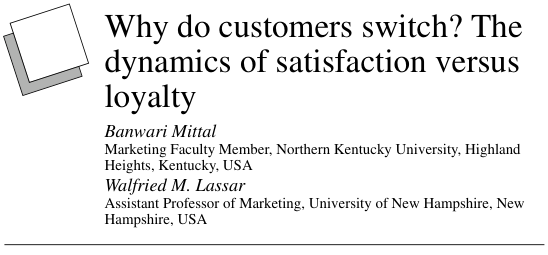

NOTE: figure/graphic rendered as an image from the PDF; its content is not machine-readable text. Caption (if any) follows as the next block.

**text found inside the figure**

Why do customers switch? The dynamics of satisfaction versus loyalty

*Banwari Mittal* Marketing Faculty Member, Northern Kentucky University, Highland Heights, Kentucky, USA *Walfried M. Lassar* Assistant Professor of Marketing, University of New Hampshire, New Hampshire, USA

*An executive summary for managers and executives can be found at the end of this article*

#### **Customer loyalty**

#### **Recruitment costs**

Page 2

[output not shown]

NOTE: table converted from PDF layout to HTML text; cell boundaries are reconstructed. See PDF if exact alignment matters.

**Conceptualizing the research questions** Customer satisfaction is a fundamental concept in marketing and its pursuit an important goal for businesses (Leavitt, 1983; Webster, 1994). Indeed, businesses of all sorts now devote considerable energies on tracking customer satisfaction. A whole new industry on satisfaction research and consulting has come into existence (e.g. Barsky, 1994; Hayes, 1992). Leading satisfaction researchers argue, “customer satisfaction drives future profitability. It is a vital measure of performance for firms, industries, and national economies” (Anderson *et al.,* 1994). Heavy use of satisfaction surveys by service industries is driven by the assumption that a satisfied customer will return for a repurchase (Jones and Sasser, 1995). Is this assumption always valid?

Accordingly, we sought to assess this question: does satisfaction always imply customer loyalty? We had two possible reasons for a negative answer: first, a dissatisfied customer may still continue his/her patronage if he/she expects no better from alternative suppliers. And second, a satisfied customer may be willing (or even eager) to patronize alternative suppliers hoping to receive even more satisfying results (Rust and Zahorik, 1993). Thus, if we found a gap between satisfaction and customer loyalty, it would question the important assumption managers unwittingly make about the satisfaction-loyalty correspondence.

In addition, we wanted to examine the linkage between satisfaction and loyalty on the one hand and measures of service quality on the other. There are several reasons for using measures of service quality to understand customer loyalty. First, satisfaction is a rating of customer’s experience with the service outcome, whereas quality is a judgment made about a firm’s

178 THE JOURNAL OF SERVICES MARKETING, VOL. 12 NO. 3 1998

#### **Tracking customer satisfaction**

Page 3

resources and skills. Unsatisfactory personal outcomes may be due to factors related to the customer’s specific characteristics, and the customer may still rate the firm high or low on quality.

For example, a consumer enrolled in a weight control program might not achieve the desired results, and hence may be dissatisfied, but he or she may blame his or her own failure to follow the regimen. On the other hand, even when he or she is successful in achieving the program results, the outcome may be seen entirely due to personal efforts, or due to a standardized regimen any one could have suggested. The consumer could even perceive that the weight control counselor was inapt in communicating, but the program was so simple that the customer could follow it on his or her own. Thus, satisfaction and quality ratings may well not correspond, and loyalty may be explained better by quality ratings than by satisfaction.

The second reason for using and measuring quality to explain loyalty is that quality ratings tell us the state of the service provider’s resources and actions, whereas satisfaction ratings tell us about the state of the consumer (see Johnson *et al.,* 1995). Measuring satisfaction only tells us whether the customer is satisfied or not, but not what to do about it. Measuring quality tells us what aspects of service are below par and need improvement.

Since we wanted to be able to obtain guidance for managers as to what aspect of service to improve, we sought to measure quality ratings for specific components of service. Yet we wanted these specific components to be generalizable to all kinds of services. That is, we wanted components that are specific in that they are conceptually distinct and managerially actionable while at the same time they should be applicable across all services.

For this reason, we used two different concepts of service quality. Both emphasize multiple components and conceptually distinct dimensions, and both are popular as well as respected in the services marketing literature. First of these is by Grönroos (1990), who has proposed that service quality consists of two dimensions:

(1) technical quality; and

(2) functional quality.

Technical quality is the quality of what is delivered: e.g. the quality and effectiveness of diagnosis and medical procedures of a hospital, the effectiveness of car repair, the cleanliness of the room in a hotel, etc. Functional quality is the quality of how the service is delivered – the care and manners of the delivery personnel. The important question we asked was, did these two forms of service quality influence satisfaction and loyalty differently?

The second conception and measure of service quality is SERVQUAL. Proposed by researchers Parasuraman *et al.* (1988), SERVQUAL measures service quality as five dimensions: reliability, responsiveness, assurance, empathy, and tangibles. These dimensions are defined as follows:

(1) *Reliability:* Ability to perform the promised service dependably and

accurately;

(2) *Responsiveness:* Willingness to help customers and provide prompt

service;

(3) *Assurance:* Knowledge and courtesy of employees and their ability to

inspire trust and confidence;

THE JOURNAL OF SERVICES MARKETING, VOL. 12 NO. 3 1998 179

#### **Measuring quality**

#### **Five dimensions of service quality**

Page 4

(4) *Empathy:* Caring, individualized attention the firm provides its

customers;

(5) *Tangibles:* Physical facilities, equipment, and appearance of personnel.

In most research studies done by SERVQUAL’s authors, Reliability has been found to be the most influential determinant of overall service quality or of customer satisfaction with the service. But an important question remains unanswered. This question is: Are the dimensions of SERVQUAL that influence satisfaction also the ones that influence loyalty? We examine this question here.

We might note that the SERVQUAL scale is not without controversy in the literature – as one reviewer pointed out. The controversy centers around such issues as the dimensionality of the scale (e.g. Babakus and Boller, 1992; Mittal and Lassar, 1996; Peter *et al.,* 1993), lack of constancy of factor structure across studies (Parasuraman *et al.,* 1988), universal applicability across diverse industries (e.g. Carman, 1990), lack of convergent validity especially when judged by factor loadings of scale items on the intended factors (e.g. Headley and Miller, 1993), and the wisdom of measuring expectations as well as perceptions, rather than just the perceptions (e.g. Cronin and Taylor, 1992). See Asubonteng *et al.* (1996) for a comprehensive critical review. We employ the scale because it has been one of the most utilized scales both in academic and applied research settings, and because at least its face validity has been acknowledged (Asubonteng *et al.,* 1996). For our purposes, both the five dimensions and their individual indicators have meaning for the two services examined here, and it is certainly of interest to investigate whether these dimensions play the same role in influencing loyalty across the two services. In particular, we wished to identify differences, if any, between reliability on the one hand (which is akin to “technical” quality), and responsiveness, assurance, and empathy on the other (the dimensions more akin to “functional” quality).

Our motivation for examining this question comes from the theory of hygienic and motivating factors for influencing employee morale and performance cited in the organization behavior literature (Herzberg, 1966). It is entirely plausible that factors that keep a customer from being dissatisfied are not the same as the ones to make him or her loyal. We thought any discovery on this question would be of value to managers.

Finally, while we seek generalizability, we wondered if there are characteristics of services which make different components of service quality influential in one type of service but not in the other. One characteristic that appeared most relevant for this purpose was the degree of interpersonal contact between the service provider and the customer (Mittal and Lassar, 1996). For example, service on possessions is a “lower” contact service than service on the person himself/herself. Illustratively, car repair is a lower contact service compared to hospital care. We would expect that “functional” quality (e.g. “how” the service is delivered) would be more influential in high contact services; and “technical” quality (e.g. “what” services are delivered) would be more influential in low contact services.

Accordingly, the following became the questions we sought to examine in the present research.

(1) Does customer satisfaction always ensure customer loyalty? Is

satisfaction merely a necessary prerequisite for loyalty, or a sufficient one? Or are satisfaction and loyalty entirely independent?

180 THE JOURNAL OF SERVICES MARKETING, VOL. 12 NO. 3 1998

#### **Controversy**

#### **Characteristics of services**

Page 5

(2) Is service quality related to satisfaction? Is it related to loyalty? Is it

related more to loyalty than to satisfaction, or vice versa?

(3) Do different components of service quality (such as functional and

technical quality) influence satisfaction differently than they influence loyalty?

(4) And, finally, does this pattern of influence differ across high contact

versus low contact service industries?

**Method** *Data collection* We selected two services, health care and car repair. Our intent was to select a service with high interpersonal contact opportunity between the customer and the service providers (health care), and another with relatively low opportunity (car repair). Since functional quality of the Grönroos’ (1990) categories, and, likewise, responsiveness and empathy dimensions of SERVQUAL would have relevance mostly for services that offer opportunities for interpersonal interaction, it was important to obtain variation on this attribute of the service organization (Mittal and Lassar, 1996).

We collected consumer responses on their experience with either of these two services. Our respondents answered a questionnaire either for a health clinic or a car repair service facility. Respondents were recruited from PTA organizations, mailbox drops, and mall intercepts in two US cities. One hundred and ten customers answered the survey for a car repair service, and 123 for a health care facility they utilized within the past one year.

*Operationalization of measures* The questionnaire contained the measures of overall satisfaction, intention to switch, technical quality, functional quality, and the SERVQUAL scale. Satisfaction was measured by this item:

Overall, with this facility, I am:

(1) Extremely dissatisfied.

(2) Somewhat dissatisfied.

(3) Feel neutral.

(4) Somewhat satisfied.

(5) Extremely satisfied.

Loyalty was measured by this item: If there was another____ that you could go to, would you switch over to it?

(1) no;

(2) perhaps; and

(3) definitely.

Technical quality was measured by this item: The overall quality of work performed by this ____ is:

(1) Very poor.

(2) Poor.

(3) Average.

(4) Good.

(5) Excellent.

THE JOURNAL OF SERVICES MARKETING, VOL. 12 NO. 3 1998 181

#### **Consumer responses**

#### **Loyalty**

Page 6

Functional quality was measured by this item: The overall quality of the service at this ____ is:

(1) Very poor.

(2) Poor.

(3) Average.

(4) Good.

(5) Excellent.

The “quality of the service” is generally interpreted by customers to refer to the way they (customers) are treated by the business firm. Specially, since this question followed the question on “the quality of work performed,” its distinction from the basic service work was highlighted.

A manipulation check verified this assumption. Compared to the second measure, the first measure had a higher correlation with an additional item we had measured, namely, “The ____ takes care of your problem effectively” (the correlation was 0.81 versus 0.71 for health clinic and 0.85 versus 0.77 for car repair service). Conversely, with yet another additional item (namely, “At ____, employees are friendly and pleasant”), the latter measure correlated more than did the former measure (correlation, 0.69 versus 0.65 for health clinic and 0.57 versus 0.52 for car repair). Thus, the two questions are deemed to capture the technical and functional facets of quality.

For SERVQUAL, we used its latest, 21-item, version (Parasuraman *et al.,* 1994), all items measured as perceptions on 5-point Likert scale;

(1) strongly disagree;

(2) disagree;

(3) feel neutral;

(4) somewhat agree; to

(5) strongly agree.

Finally, we also assessed selected demographics and a few questions for exploratory purposes.

In the marketing literature, consumer loyalty has generally been measured as preponderance or bias of past behavioral frequency in favor of a specific brand (e.g. Dick and Basu, 1994). However, such a measure is more suited to consumer goods. For services (particularly for high involvement services that are examined in this research), the measure likely to be most useful to managers is the one that questions respondents on their predisposition to switching suppliers or service providers. We used this measure to assess the loyalty the respondents felt toward their present health care and car repair service providers. A further point of clarification is that we used only three response categories because of the small sample size; a more graduated scale would have yielded a rather small cell size of switchers. Moreover, we would have had to subsequently use an arbitrary dividing line to regroup respondents into loyal and not-loyal customers. The three-point scale, with fewer in-between categories, reduces the need for such arbitrary regrouping by researchers. Nevertheless, our measure of customer loyalty must be viewed as imperfect. In the discussion section, we suggest improvement in the measure for future research.

182 THE JOURNAL OF SERVICES MARKETING, VOL. 12 NO. 3 1998

#### **“Quality of the service”**

#### **Assessing the loyalty**

Page 7

[output not shown]

NOTE: table converted from PDF layout to HTML text; cell boundaries are reconstructed. See PDF if exact alignment matters.

THE JOURNAL OF SERVICES MARKETING, VOL. 12 NO. 3 1998 183

Page 8

or even “5” on technical quality, a substantial proportion of customers would switch (see Table I).

These “loyalty implications” of “technical quality” ratings are replicated with “functional quality.” See Table I. Even with a “quality of service” rating of “excellent” (e.g. “5”), as many as 18.18 percent (for health care) and 31.25 percent (car repair) customers would switch.

*Satisfied versus dissatisfied customers* Which dimensions of service quality drive customer satisfaction? Recall that we measure two forms of service quality: technical and functional. We sought to examine the effect of these two forms of service quality on customer satisfaction. For this purpose, we divided the respondents, as before, into two groups:

(1) dissatisfied (rating <3); and

(2) satisfied (rating >3) customers.

Then we utilized the two forms of quality as predictors in a discriminant analysis. Discriminant analysis is a statistical technique that shows which factor discriminates between two (or more) groups of customers, such as satisfied and dissatisfied customers. The results are shown in Table II.

The results show that for health care services, functional quality played a more significant role than did technical quality (discriminant coefficient 0.679 for the former versus 0.444 for the latter). In contrast, for car repair services, technical quality played a more significant role than did functional quality (signified by the discriminant coefficient of 0.755 for the former compared to 0.333 for the latter). See Table II, Panel “A”.

We repeated the same analysis using SERVQUAL dimensions. In SERVQUAL, Reliability can be deemed to represent “technical quality,”

184 THE JOURNAL OF SERVICES MARKETING, VOL. 12 NO. 3 1998

*Table I. Inclination to switch as a function of satisfaction, technical quality, and functional quality*

[output not shown]

NOTE: table converted from PDF layout to HTML text; cell boundaries are reconstructed. See PDF if exact alignment matters.

#### **Discriminant analysis**

Page 9

whereas the Responsiveness, Assurance, and Empathy dimensions reflect “functional quality”[1]. Therefore, these three dimensions were combined to compute a total score. As Table II, Panel “B” shows, the results with SERVQUAL are similar to those obtained with technical and functional quality in Panel “A”[2]. In fact, for health care services, Reliability fails to enter the discriminant function; that is, it does not make a significant contribution beyond the determinant role played by Responsiveness/ Assurance/Empathy.

*Explaining switching versus loyalty behavior* We repeated similar discriminant analyses, this time to discriminate those who are inclined to switch versus those who are not, limiting the analysis to those who are satisfied. Since we know that dissatisfaction almost always causes disloyalty, and from the foregoing analysis, we know which of the two forms of quality affects dissatisfaction, our interest here was to analyze customers who have propensity to switch despite satisfaction. Thus, we took only those respondents who are satisfied, and identified groups of likely “nonswitchers” and “switchers” (the latter group comprising those who said they would “perhaps” or “definitely” switch). The results of discriminant analyses for these two groups are presented in Table III.

In one of the discriminant analyses, we used functional and technical quality as predictors. As results presented in Table III, Panel “A” show, for health care services, technical quality played a more significant role in creating

THE JOURNAL OF SERVICES MARKETING, VOL. 12 NO. 3 1998 185

*Table II. Discriminators of satisfaction; satisfied (rating >3) vs dissatisfied (rating <3) customer groups*

[output not shown]

NOTE: table converted from PDF layout to HTML text; cell boundaries are reconstructed. See PDF if exact alignment matters.

#### **“Nonswitchers” and “switchers”**

Page 10

loyalty (e.g., nonswitching) than did functional quality (discriminant coefficient 0.676 versus 0.386). For car repair services, the converse was the case: in fact, only functional quality was significant.

Moreover, factors driving satisfaction and loyalty differed, and they differed also across the two service categories examined. The discriminant

186 THE JOURNAL OF SERVICES MARKETING, VOL. 12 NO. 3 1998

*Table III. Discriminators of switching behavior; switchers vs non-switchers within the satisfied (rating >3) customer group*

[output not shown]

NOTE: table converted from PDF layout to HTML text; cell boundaries are reconstructed. See PDF if exact alignment matters.

#### **Results of a discriminant analysis**

#### **Managerial overview**

Page 11

coefficients reported in Table II and III are pulled together in Figures 1 and 2. As Figure 1 depicts, for health care services, satisfaction is driven more by functional than technical quality, while loyalty (e.g., inclination to not switching) is driven more by technical than by functional quality.

In contrast, for car repair services, Figure 2 shows that satisfaction is driven by technical quality more than it is driven by functional quality, whereas loyalty is driven more by functional than by technical quality.

*The dynamics of satisfaction versus loyalty* The foregoing statement about what drives loyalty should be understood with the proviso that loyalty is not entirely divorced from satisfaction. The disloyalty/loyalty groups contrasted are from a subpopulation that is already satisfied. Dissatisfied customers are almost always prone to switch (as our data show). That is hardly news. What is news is that even some satisfied customers would switch. In separating disloyal versus loyal customers, therefore, managers have to ask what drives loyalty beyond satisfaction.

THE JOURNAL OF SERVICES MARKETING, VOL. 12 NO. 3 1998 187

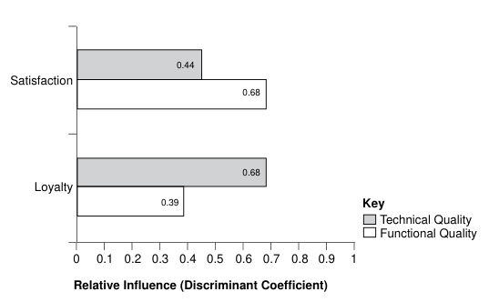

NOTE: figure/graphic rendered as an image from the PDF; its content is not machine-readable text. Caption (if any) follows as the next block.

**text found inside the figure**

Satisfaction

Loyalty

0.44

0.68

0.39

0.68

0 0.1 0.2 0.3 0.4 0.5 0.6 0.7 0.8 0.9

**Relative Influence (Discriminant Coefficient)**

1

**Key**

Technical Quality Functional Quality

*Figure 1. Drivers of satisfaction and loyalty for health care services*

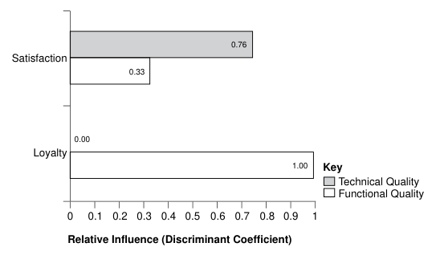

NOTE: figure/graphic rendered as an image from the PDF; its content is not machine-readable text. Caption (if any) follows as the next block.

**text found inside the figure**

Satisfaction

Loyalty

0.76

0.33

1.00

0.00

0 0.1 0.2 0.3 0.4 0.5 0.6 0.7 0.8 0.9 1

**Relative Influence (Discriminant Coefficient)**

**Key**

Technical Quality Functional Quality

*Figure 2. Drivers of satisfaction and loyalty for car repair services*

#### **What drives loyalty?**

Page 12

[output not shown]

NOTE: table converted from PDF layout to HTML text; cell boundaries are reconstructed. See PDF if exact alignment matters.

For the health care services, if the service is delivered in an uncaring manner, patients will be dissatisfied even more than if the medical problem is poorly resolved. How could that be? We offer two explanations for this. One, the medical conditions typically take time to improve whereas the interpersonal experience is immediate and direct – patients are handled by admissions staff and by paramedical persons even before they see the doctor. Moreover, in their suffering, patients are looking for some caring and comfort at the moment, rather than immediate relief from the physical pain. Thus, how well they were treated as a person forms a more direct and preemptive impression on them. (For a discussion of the role of interpersonal interaction in service encounters, see Adelman *et al.,* 1984; Bitner *et al.,* 1994; Crosby *et al.,* 1990; Kelley, 1992; Mittal and Lassar, 1996; Price *et al.,* 1995; Solomon *et al.,* 1985.)

Secondly, since patients do not have the expertise to judge the technical quality of medical services, they might attribute a failure of treatment to their own condition rather than to the care-giver’s competence and control. In fact, their judgments of technical quality themselves may be driven by their experience with the functional quality. For example, if the doctor is friendly, he/she may be viewed also as being skilled. Thus, functional quality (e.g. mannerism and responsiveness of staff) become the immediate and visible source of satisfaction with the service provider.

What about loyalty beyond satisfaction? Consider a patient who needs hospital service the next time. She/he recalls how well the staff behaved, but also that her/his ailment was not really cured. Should not she/he rather try a new hospital or doctor this time to ensure more effective treatment? Thus, while the functional quality may have led the patient to be satisfied, if the

188 THE JOURNAL OF SERVICES MARKETING, VOL. 12 NO. 3 1998

#### **Interpersonal interaction in service encounters**

Page 13

technical quality turned out to not entirely resolve the patient’s problem, the patient is inclined to try another provider next time, as our data show.

*Limitations* Obviously, our data are limited in their representation. Only one instance of each service category was included. Also, respondents were drawn from a convenience sample, and sample sizes were small. Our results need to be replicated for a larger and more representative sample of both service categories and consumers. Future research should sample service categories not only to include variability on the “opportunity for interpersonal contact,” but also variability on the degree to which it is possible for customers to judge a firm’s technical quality. For services with “credence quality” (e.g. where technical quality cannot be assessed and has to be assumed on faith or reputation of the service provider), customers might base their judgments of technical quality itself on their experience of the functional quality[3]. This issue needs to be more focally examined in future research.

Another limitation of our research was to rely on less-than-ideal measures of two key concepts: technical versus functional quality and loyalty. Each was measured by a single item indicator. In future research, it would be useful to test and employ multiple item scales for these key concepts. For example, loyalty might be measured by intent to switch (as done here), a feeling of commitment to the present supplier (e.g. “I feel a sense of personal commitment to this car mechanic”), being closed to listening to alternative suppliers’ pitches (e.g. “I would/would not like to receive sales brochures or promotional materials from other hospitals in the area”), being in the habit of comparison shopping (e.g. “I am always on the look out for other car repair garages that might offer me better deals”). In the same vein, technical quality can be measured by such additional items as “the hospital does an effective job of curing your ailment”, “the hospital staff is highly qualified to take care of your medical problem”, etc. Likewise, functional quality can be measured by such additional items as “the hospital treats you like an individual, not a statistic”, “My interactions with the hospital staff were entirely delightful”. Although the use of such multiple measures will lengthen the survey form (keeping them short is an important goal in application research), their use at least in some replication research will help raise our confidence in the findings of the present paper.

*Managerial implications* Although more research is needed for a variety of service industries, some management lessons are already clear from our research. These are outlined below:

(1) First of all, managers ought not to be contented with a good satisfaction

score – certainly not with a score of “4” on a five point scale, but also not with a score of “5”. Of course, poor satisfaction ratings should concern managers deeply as they do; but a “top box” satisfaction score should still be no cause for celebration (see Jones and Sasser (1995) for further evidence on this point). Some 20 to 30 percent of our “top box” respondents are inclined to switch!

(2) In addition to measuring satisfaction, managers must also measure

THE JOURNAL OF SERVICES MARKETING, VOL. 12 NO. 3 1998 189

#### **Two key concepts**

#### **Management lessons**

Page 14

[output not shown]

NOTE: table converted from PDF layout to HTML text; cell boundaries are reconstructed. See PDF if exact alignment matters.

190 THE JOURNAL OF SERVICES MARKETING, VOL. 12 NO. 3 1998

Page 15

dominant dissatisfaction/satisfaction driver. For a low contact service, the firm already delivering a high level of satisfaction should invest in functional quality (e.g. in interpersonal skills); in contrast, for a high contact service, such a firm should invest in technical quality (equipment, technology, professional expertise) so as to convert satisfied customers into loyal patrons.

(8) Our research is relevant to not only the service businesses *per se* but

also to many retail businesses that feature customer service or customized offerings, such as jewelry stores, custom decorating, custom clothing, photography, and other instances of customer education and service-based selling.

*Conclusion* Notwithstanding the popularity of satisfaction surveys in service industries, the dynamics of satisfaction and loyalty defy intuitive assumptions managers typically make. It turns out that the relationship between satisfaction and loyalty is asymmetrical: while dissatisfaction nearly guarantees switching, satisfaction does not ensure loyalty.

Even more importantly, the drivers of “loyalty beyond satisfaction” are different from what drives dissatisfaction versus satisfaction. In our data, the potency of technical quality (“the quality of the work performed”) and functional quality (“the quality of the service”) in delivering satisfaction and loyalty differed. And it varied between a low contact and a high contact service. For a low contact service (e.g. car repair), technical quality was needed to first obtain satisfaction, and then functional quality was needed to drive loyalty beyond satisfaction. The converse was the case for a high contact (e.g. health care) service.

This pattern of findings should guide managers in designing satisfaction and loyalty measurement research in their particular firms. The analysis we employed can also serve as a prototype. Managers can analyze the satisfaction and loyalty data to identify whether the technical or the functional quality improvement is the critical need for their firms at a particular juncture in their service operations. This analysis should help guide a service firm’s investment in appropriate quality initiatives.

#### **Notes**

1. In our data, the three dimensions were highly correlated and yielded a single factor. 2. The dimension of tangibles was also entered as a discriminator; however, it proved nonsignificant in all of the analyses reported here. 3. The concept of “credence” quality is due to Darby and Karni (1973).

**References** Adelman, M.B., Ahuvia, A. and Goodwin, C. (1984), “Beyond smiling: social support and

service quality”, in Rust, R.T. and Oliver, R.L. (Eds), *Service Quality: New Directions in Theory and Practice,* Sage, Thousand Oaks, CA, pp. 139-72. Anderson, E.W., Fornell, C. and Lehman, D.R. (1994), “Customer satisfaction, market share,

and profitability”, *Journal of Marketing,* Vol. 58, July, pp. 53-66. Asubonteng, P., McLeary, K.J. and Swan, J.E. (1996), “SERVQUAL revisited: a critical

review of service quality”, *Journal of Services Marketing,* Vol. 10 No.6, pp. 62-81. Babakus, E. and Boller, G.W. (1992), “An empirical assessment of the SERVQUAL scale”,

*Journal of Business Research,* Vol. 24, pp. 253-68. Barsky, J. (1994), *World-Class Customer Satisfaction,* Irwin Professional Publishing, Burr

Ridge, IL.

THE JOURNAL OF SERVICES MARKETING, VOL. 12 NO. 3 1998 191

#### **“Loyalty beyond satisfaction”**

Page 16

Berry, L.L. (1980), “Services marketing is different”, *Business,* Vol. 30, May, pp. 24-9. Bitner, M.J., Booms, B.H. and Mohr, L.A. (1994), “Critical service encounters: the employee’s

viewpoint”, *Journal of Marketing,* Vol. 58, October, pp. 95-106. Cannie, J.K. (1992), *Turning Lost Customers into Gold,* AMACOM, New York, NY. Cronin, J.J. Jr. and Taylor, S.A. (1992), “Measuring service quality: a re-examination and

extension”, *Journal of Marketing,* Vol. 56, July, pp. 55-68. Crosby, L.A., Evans, K.R. and Cowles, D. (1990), “Relationship quality in services selling: an

interpersonal influence perspective”, *Journal of Marketing,* Vol. 54 No. 3, pp. 68-81. Darby, M.R. and Karni, E. (1973), “Free competition and optimal amount of fraud”, *Journal of*

*Law and Economics,* Vol. 16, April, pp. 67-86. Dick, A.S. and Basu, K. (1994), “Customer loyalty: toward an integrated conceptual

framework”, *Journal of the Academy of Marketing Science,* Vol. 22, Spring, pp. 99-113. Grönroos, C. (1990), “Relationship approach to marketing in service contexts: the marketing

and organizational behaviour interface”, *Journal of Business Research,* Vol. 20, January, pp. 3-11. Hayes, B.E. (1992), *Measuring Customer Satisfaction,* ASQC Quality Press, Milwaukee, WI. Headley, D.E. and Miller, S.J. (1993), “Measuring service quality and its relationship to future

consumer behavior”, *Journal of Health Care Marketing,* Vol. 13 No. 4, pp. 32-41. Herzberg, F. (1966), *Work and the Nature of Man,* Cleveland World Press, Cleveland, OH. Johnson, R.L., Tsiros, M. and Lancioni, R.A. (1995), “Measuring service quality: a systems

approach”, *Journal of Services Marketing,* Vol. 9 No. 5, pp. 6-19. Jones, T.O. and Sasser, Jr W.E. (1995), “Why satisfied customers defect”, *Harvard Business*

*Review,* November-December, pp. 88-99. Keaveney, S.M. (1995), “Customer switching behavior in service industries: an exploratory

study”, *Journal of Marketing,* Vol. 59 No. 2, pp. 71-82. Kelley, S.W. (1992), “Developing customer orientation among service employees”, *Journal of*

*the Academy of Marketing Science,* Vol. 20 No. 1, pp. 27-36. Leavitt, T. (1983), *The Marketing Imagination,* The Free Press, New York, NY. Lovelock, C.H. (1991), *Services Marketing,* Prentice Hall, Englewood Cliffs, NJ. Mittal, B. and Lassar, W.M. (1996), “The role of personalization in service encounters”,

*Journal of Retailing,* Vol. 72 No. 1, pp. 95-109. Parasuraman, A., Zeithaml, V.A. and Berry, L.L. (1988), “SERVQUAL: a multiple-item scale

for measuring consumer perceptions of service quality”, *Journal of Retailing,* Vol. 64, Spring, pp. 12-40. Parasuraman, A., Zeithaml, V.A. and Berry, L.L. (1994), “Alternative scales for measuring

service quality: a comparative assessment based on psychometric and diagnostic criteria”, *Journal of Retailing,* Vol. 70 No. 3, pp. 201-30. Peppers, D. and Rogers, M. (1993), *The One to One Future: Building Relationships One*

*Customer at a Time,* Doubleday, New York, NY. Peter, J.P., Churchill, G.A. Jr and Brown, T. (1993), “Caution in the use of difference scores in

consumer research”, *Journal of Consumer Research,* Vol. 19, March, pp. 61-71. Price, L.L., Arnould, E.J. and Tierney, P. (1995), “Going to extremes: managing service

encounters and assessing provider performance”, *Journal of Marketing,* Vol. 59, April, pp. 83-97. Reichheld, F. and Sasser, W.E. Jr (1990), “Zero defections: quality comes to services”,

*Harvard Business Review,* Vol. 68, September/October, pp. 105-11. Rust, R.T. and Zahorik, A.J. (1993), “Customer satisfaction, customer retention, and market

share”, *Journal of Retailing*, Vol. 69, Summer, pp. 193-215. Sheth, J. and Mittal, B. (1996), “Securing customer loyalty”, *GAMA News Journal,* May-June,

pp. 4-7. Solomon, M.R., Surprenant, C.F., Czepiel, J.A. and Gutman, E.G. (1985), “A role theory

perspective on dyadic interactions: the service encounter”, *Journal of Marketing,* Vol. 49, Winter, pp. 99-111. Webster, F.W. (1994), “Executing the new marketing concept”, *Marketing Management,* Vol. 3

No. 1, pp. 9-16. Zeithaml, V.A., Berry, L.L. and Parasuraman, A. (1996), “The behavioral consequences of

service quality”, *Journal of Marketing,* Vol. 60, April, pp. 31-46.

#### I

192 THE JOURNAL OF SERVICES MARKETING, VOL. 12 NO. 3 1998

Page 17

#### **Executive summary and implication for managers and executives**

*Satisfied customers are the start of your loyalty campaign not the end* *Here’s a dilemma for managers. Even when your customers say they’re satisfied they still switch to other suppliers. What do these consumers want? Blood? We go to great lengths making sure we have satisfied customers and they reward our efforts by switching to our competitor! The truth is what we’ve always suspected. Satisfied customers aren’t necessarily loyal customers. Indeed loyalty requires a commitment from the customer that mere satisfaction cannot bring.*

*Mittel and Lassar consider this dilemma by looking at whether the same factors influence loyalty as influence satisfaction. They confirm that customers “… who report a high satisfaction rating still possess a predisposition to switch service suppliers.” And we also see that (not surprisingly) dissatisfied customers will definitely switch so you can’t ignore satisfaction.*

*But Mittel and Lassar’s most important finding is that the “type” of quality affecting satisfaction differs from that affecting loyalty. If satisfaction follows from functional quality (empathy, responsiveness, assurance) then loyalty comes from technical quality (reliability). Similarly satisfaction derived from technical quality means loyalty results from functional quality.*

*The implications of these findings are enormous. First it tells us that customer satisfaction measures are inadequate on their own and need supplementing by a measure of loyalty (in this study the propensity to switch supplier). And secondly it means that we cannot focus on those elements of quality creating satisfaction because they don’t encourage loyalty. The findings provide clarity – and answer the switching dilemma – but they make service managers’ job harder still.*

*In the spirit of this discovery I intend to set out how managers should respond to Mittel and Lassar’s important discovery. And, in doing so, I shall provide some guidance for service improvements leading to loyalty:*

*(1) The first task of service managers is to understand what kind of service*

*they provide. Is it a “credence” service where functional quality determines satisfaction or an “experience” service where technical quality matters? Any quality strategy must start from this point.*

*(2) Next the service manager must establish the basic requisites of customer*

*satisfaction. There’s no use focusing on loyalty if you’ve got unhappy customers. We must identify and eliminate the causes of dissatisfaction and stress improvements in areas that drive customer satisfaction. If it’s functional quality then concentrate on customer care, ambience, convenience and responsiveness. If it’s technical competence that matters recruit trained staff and make sure they deliver high quality work. Borrow ideas from product quality improvement such as quality circles, quality checks and “right first time”.*

*(3) When your measures show the vast majority of customers as satisfied*

*the emphasis needs to switch to promoting loyalty. This means concentrating on the opposite quality type – functional quality for some and technical quality for others. The medical centre with caring, responsive reception and nursing staff needs the best medical staff to make satisfied customers loyal. The car repair centre that fixes cars well should focus on staff-customer interaction, responsiveness, comfort and*

THE JOURNAL OF SERVICES MARKETING, VOL. 12 NO. 3 1998 193

*This summary has been provided to allow managers and executives a rapid appreciation of the content of this article. Those with a particular interest in the topic covered may then read the article* in toto *to take advantage of the more comprehensive description of the research undertaken and its results to get the full benefit of the material present*

Page 18

*customer care. You will need to use a measure of loyalty alongside established satisfaction measures.*

*(4) The service manager should consider how to use the strength of a loyal,*

*happy customer base as a way of recruiting new customers. Direct mail, quality-referenced advertising (see Green, this issue of* JSM*) and “recommend-a-friend” campaigns can all assist is exploiting satisfaction and loyalty.*

*(5) Managers can also begin to develop new services to sell to newly loyal*

*customers. As Mittel and Lassar point out, loyal customers “… progress to buying more of their total requirements from one supplier …” resulting in a greater “… lifetime revenue from that customer.” UK tyre and puncture repair company, Kwik-Fit, used its reputation for service and a loyal customer base to sell exhaust systems, oil changes, wheels and even car insurance.*

*Loyalty represents the aim of a service business. More loyal customers means lower marketing costs, more efficient operations and, most important, higher profits. For years businesses have thrashed around in the dark trying to promote customer loyalty. This has meant either “bribing” customers with rewards, sales promotions, “points-mean-prizes” schemes and the like or else using satisfaction as a surrogate for loyalty. What Mittel and Lassar show is how satisfaction is a prerequisite for loyalty but isn’t sufficient on its own.*

*And, to my mind, the findings here establish that sales promotions are not the way to create loyalty. Loyalty isn’t price sensitive and using price to instil loyalty creates loyalty to the sales promotion rather than loyalty to the business. It’s much harder than it seems to create loyalty but, for the company that succeeds, the rewards are enormous.*

*Customers will remain fickle – always remember they’ve no reason to remain loyal. And your competitors (especially those without your commitment to customer satisfaction and service) will use every trick in the book to tempt customers away from you. By becoming exceptional in your service quality you will resist these pressures and set yourself in good stead to grow and succeed.*

(A précis of the article “Why do customers switch? The dynamics of satisfaction versus loyalty”. Supplied by Marketing Consultants for MCB University Press.)

194 THE JOURNAL OF SERVICES MARKETING, VOL. 12 NO. 3 1998